# Part II - PISA Data

## by Abdessalam Dai

## Investigation Overview

In this investigation, I wanted to look more closely at the environmental factors that both parents and students brought to the overall PISA scores, the differences in scores between the sexes, and the countries that performed the best. Gender, parental presence at home, and country were the main considerations.

## Dataset Overview

PISA is a survey of students' skills and knowledge as they approach the end of compulsory education. It is not a conventional school test. Rather than examining how well students have learned the school curriculum, it looks at how well prepared they are for life beyond school.

Around 510,000 students in 65 economies took part in the PISA 2012 assessment of reading, mathematics and science representing about 28 million 15-year-olds globally. Of those economies, 44 took part in an assessment of creative problem solving and 18 in an assessment of financial literacy.

## Score VS Gender

- Male students outperform female students in math while female students outperform male students in reading. In terms of average science scores, both genders are almost equal.
- Males consistently perform better than females in math. But when it comes to reading, it's the opposite.

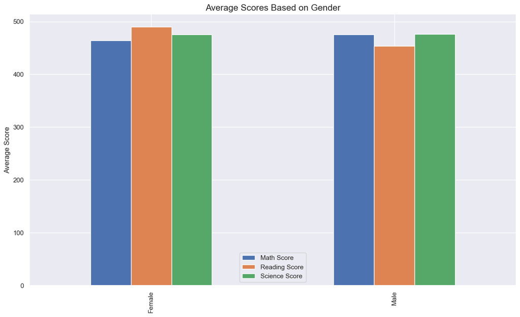

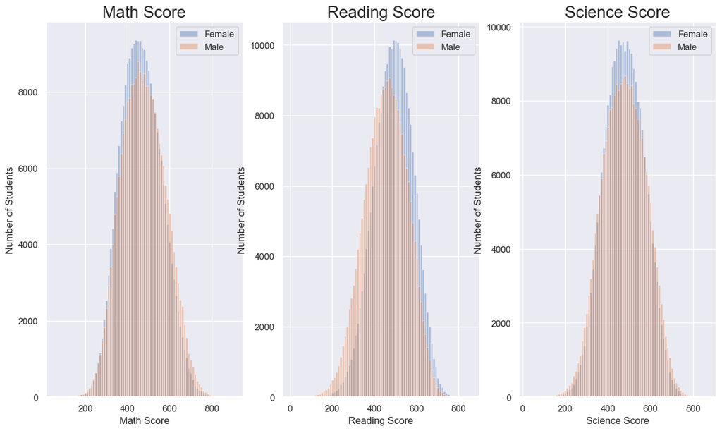

## Parental Companionship in Math, Reading and Science

If at least one parent is home, the child scores higher than a child whose parents are not home.

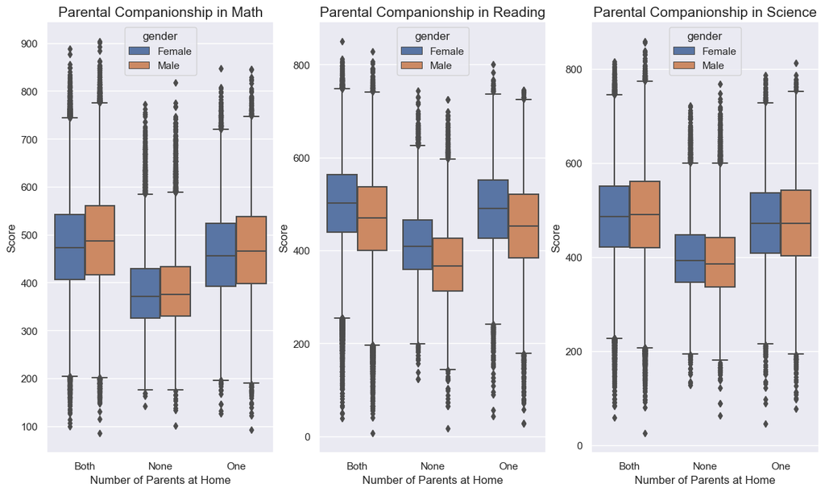

## Average Score in Different Countries for Each Subject

Here, we can see how different scores are distributed among the various countries.

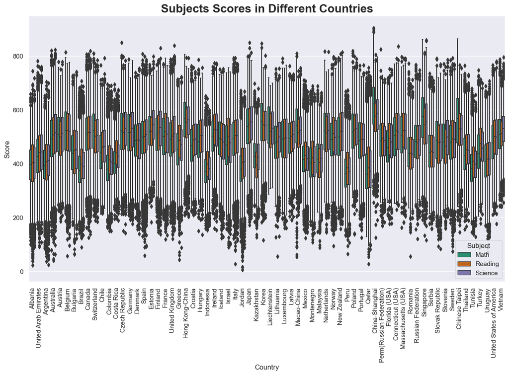